# Pakistan_GLM

Volker Dickhardt

7 Januar 2020

# 1. Data preperation

#### Load packages:

```r
library("raster")
library("rgdal")
```

```r
library("maptools")
library("geonames")
library("dismo")
```

#### Clear workspace

```r
rm(list=ls())
```

#### set working directory

```r
wd <- "E:/Uni/5. Semester/Pakistan_Projekt/bsc-sdm-2019-sharing/presentations/GLM_Volker"
setwd(wd)
dir()
```

```
## [1] "generalized Linear models.Rmd" "glm_trees.Rmd"
## [3] "glm2.2"                        "glm3.Rmd"
## [5] "Pakistan_GLM.html"             "Pakistan_GLM.Rmd"
```

#### sets a seed

```r
set.seed(0)
```

#### Read in the Shapefile “distribution_merged_Pakistan”, These file shows the records of the individual species of butterflys in Pakistan.

```r
butterflys <- readOGR("E:/Uni/5. Semester/Pakistan_Projekt/bsc-sdm-2019/data/distribution/distribution_merged_Pakistan")
```

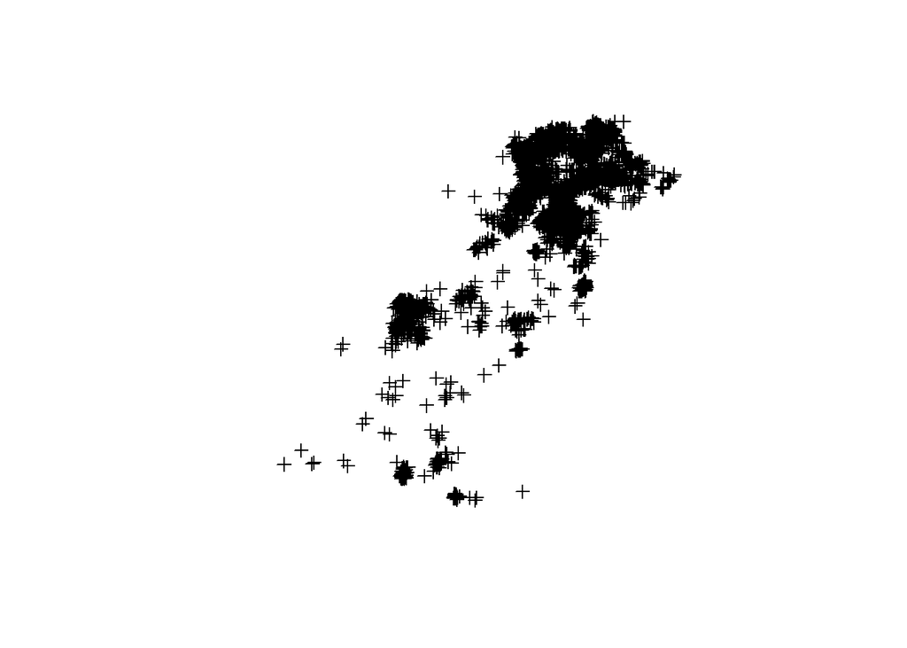

```r
plot(butterflys)
```

#### This code extracts the coordinates of the records out of the shapefile and write them into a new dataframe called butterf

```r
head(butterflys)
```

```
##                species subspecies id
## 1      Actinor_radians       <NA>  0
## 2      Actinor_radians       <NA>  0
## 3      Actinor_radians       <NA>  0
## 4 Aeromachus_stigmatus       <NA>  0
## 5 Aeromachus_stigmatus       <NA>  0
## 6 Aeromachus_stigmatus       <NA>  0
```

```r
but_cor<-coordinates(butterflys) # gives the coordinates
butterf<-as.data.frame(but_cor)
colnames(butterf) = c('lon','lat')
```

#### For this example we need the records of one species (Parnara bada)

```r
Parnara_bada <- butterf[111:145,] # extracts the coordinates of Parnara bada
```

```r
chel1 <- raster("E:/Uni/5. Semester/Pakistan_Projekt/Daten/Raster/Chelsa/annual_global_prec/CHELSA_bio10_12.tif")
chel2 <- raster("E:/Uni/5. Semester/Pakistan_Projekt/Daten/Raster/Chelsa/Annual_mean_Temperature/anual_mean_T.tif")
chel3 <- raster("E:/Uni/5. Semester/Pakistan_Projekt/Daten/Raster/Chelsa/Precipitation of Warmest Quarter/CHELSA_bio10_18.tif")
chel4 <- raster("E:/Uni/5. Semester/Pakistan_Projekt/Daten/Raster/Chelsa/warmest_quarter_mean_T_global/CHELSA_bio10_10.tif")

files<-c(chel1,chel2,chel3,chel4)
chelsa <- raster::stack(files) # stacks the Layers together

chelsa
```

```
## class      : RasterStack
## dimensions : 20880, 43200, 902016000, 4  (nrow, ncol, ncell, nlayers)
## resolution : 0.008333333, 0.008333333  (x, y)
## extent     : -180.0001, 179.9999, -90.00014, 83.99986  (xmin, xmax, ymin, ymax)
## crs        : +proj=longlat +datum=WGS84 +no_defs +ellps=WGS84 +towgs84=0,0,0
## names      : CHELSA_bio10_12, anual_mean_T, CHELSA_bio10_18, CHELSA_bio10_10
## min values :          -32768,         -173,          -32768,          -32768
## max values :           32767,          290,           32767,           32767
```

```r
nlayers(chelsa) # shows the number of layers in the raster stack
```

```
## [1] 4
```

```r
crs(chelsa) # shows the coordinate referent system of the layer
```

```
## CRS arguments:
##  +proj=longlat +datum=WGS84 +no_defs +ellps=WGS84 +towgs84=0,0,0
```

#### Load the Rasterlayer “Population of Pakistan”

```r
pop_pak <- raster("E:/Uni/5. Semester/Pakistan_Projekt/Daten/Raster/DivaGIS/pop_pak.tif")
pop_pak
```

```
## class      : RasterLayer
## dimensions : 400, 501, 200400  (nrow, ncol, ncell)
## resolution : 0.0340625, 0.0340625  (x, y)
## extent     : 60.81667, 77.88198, 23.56667, 37.19167  (xmin, xmax, ymin, ymax)
## crs        : +proj=longlat +datum=WGS84 +no_defs +ellps=WGS84 +towgs84=0,0,0
## source     : E:/Uni/5. Semester/Pakistan_Projekt/Daten/Raster/DivaGIS/pop_pak.tif
## names      : pop_pak
## values     : 1, 7548  (min, max)
```

```r
crs(pop_pak) #shows the coordinate reference system of the Layer
```

```
## CRS arguments:
##  +proj=longlat +datum=WGS84 +no_defs +ellps=WGS84 +towgs84=0,0,0
```

#### Loads the three Worldclim-Layers, Source: http://worldclim.org/version2

```r
wc_tavg<-raster("E:/Uni/5. Semester/Pakistan_Projekt/Daten/Raster/Worldclim/worldclim_temp_avg/tavg_mean.tif",pattern = ".tif", full.names = TRUE)
wc_tavg
```

```
## class      : RasterLayer
## dimensions : 21600, 43200, 933120000  (nrow, ncol, ncell)
## resolution : 0.008333333, 0.008333333  (x, y)
## extent     : -180, 180, -90, 90  (xmin, xmax, ymin, ymax)
## crs        : +proj=longlat +datum=WGS84 +no_defs +ellps=WGS84 +towgs84=0,0,0
## source     : E:/Uni/5. Semester/Pakistan_Projekt/Daten/Raster/Worldclim/worldclim_temp_avg/tavg_mean.tif
## names      : tavg_mean
```

```r
wc_tmax<-raster("E:/Uni/5. Semester/Pakistan_Projekt/Daten/Raster/Worldclim/worldclim_temp_max/tmax_mean.tif",pattern = ".tif", full.names = TRUE)
wc_tmax
```

```
## class      : RasterLayer
## dimensions : 21600, 43200, 933120000  (nrow, ncol, ncell)
## resolution : 0.008333333, 0.008333333  (x, y)
## extent     : -180, 180, -90, 90  (xmin, xmax, ymin, ymax)
## crs        : +proj=longlat +datum=WGS84 +no_defs +ellps=WGS84 +towgs84=0,0,0
## source     : E:/Uni/5. Semester/Pakistan_Projekt/Daten/Raster/Worldclim/worldclim_temp_max/tmax_mean.tif
## names      : tmax_mean
```

```r
wc_tmin<-raster("E:/Uni/5. Semester/Pakistan_Projekt/Daten/Raster/Worldclim/worldclim_temp_min/tmin_mean.tif",pattern = ".tif", full.names = TRUE)
wc_tmin #For this layers I calculated the mean in Q-GIS
```

```
## class      : RasterLayer
## dimensions : 21600, 43200, 933120000  (nrow, ncol, ncell)
## resolution : 0.008333333, 0.008333333  (x, y)
## extent     : -180, 180, -90, 90  (xmin, xmax, ymin, ymax)
## crs        : +proj=longlat +datum=WGS84 +no_defs +ellps=WGS84 +towgs84=0,0,0
## source     : E:/Uni/5. Semester/Pakistan_Projekt/Daten/Raster/Worldclim/worldclim_temp_min/tmin_mean.tif
## names      : tmin_mean
```

#### Stack the worldclim layers together

```r
wc_layers <- c(wc_tavg,wc_tmax,wc_tmin)
wc<-stack(wc_layers)
```

#### Creates an extent with the extent of the Population Layer

```r
ext <- extent(c(60, 78, 23, 38))
```

#### With the comand “crop” you cut out a raster layer with a polygon, in this case with the extent.

```r
chelsa_ext<-crop(chelsa,ext)
pop_pak_ext<-crop(pop_pak,ext)
wc_ext<-crop(wc,ext)
```

#### Now we can stack the layers together

```r
b <- c(chelsa_ext,wc_ext)
predictors <- stack(b)
```

#### We can check the data by plotting a map with the first Layer of the predictors and all records

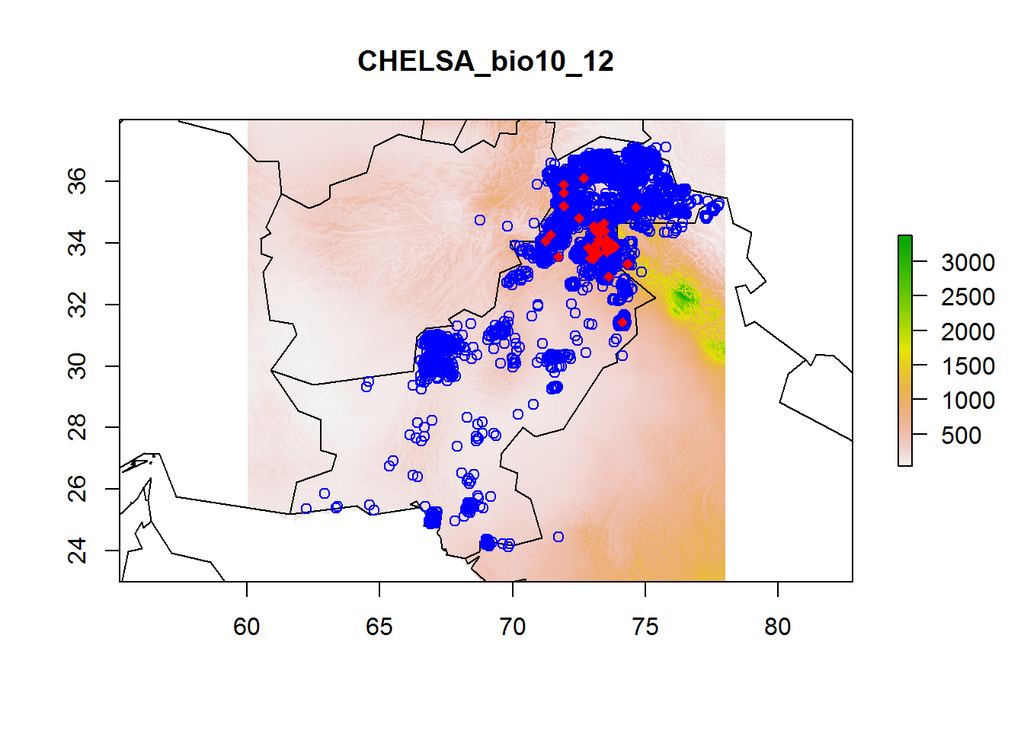

```r
data(wrld_simpl)
plot(predictors, 1)
plot(wrld_simpl, add=TRUE)
points(butterf, col='blue')
points(Parnara_bada, col="red", pch=18)
```

#### We need some background data for the absent data, This funktion creates random Points in the observation area

```r
backgr <- randomPoints(predictors, 500)
```

#### For a generalized linear model we need present and absent data. In the vektor “presvals” are the values of the predictor layers at the lokation of the records. In “absvals” are the values at the lokation of the randam points.

```r
presvals <- extract(predictors, Parnara_bada)
absvals <- extract(predictors, backgr)
```

#### We create a vektor (pb) witch writes for absent data 0 and for present data 1. Afterwards we build a dataframe with this vector and the present and absent data

```r
pb <- c(rep(1, nrow(presvals)), rep(0, nrow(absvals)))
sdmdata <- data.frame(cbind(pb, rbind(presvals, absvals)))
```

#### The command kfold gives every recort in the dataframe a number between 1 and k (in this case 5). We need this operation to get train and test data to test the model later on.

```r
group <- kfold(Parnara_bada, 5)
pres_train <- Parnara_bada[group != 1, ]
pres_test <- Parnara_bada[group == 1, ]
```

#### Now we do the same for the background data

```r
backg <- randomPoints(predictors, n=1000, ext=ext, extf = 1.05) # With extf the extent increases
colnames(backg) = c('lon','lat')
group <- kfold(backg, 5)
backg_train <- backg[group != 1, ]
backg_test <- backg[group == 1, ]
```

#### We create a matrix out of the present and background training data

```r
train <- rbind(pres_train, backg_train)
```

#### We build a dataframe with the training data and the predictor layers

```r
pb_train <- c(rep(1, nrow(pres_train)), rep(0, nrow(backg_train)))
envtrain <- extract(predictors, train)
envtrain <- data.frame( cbind(pa=pb_train, envtrain) )
head(envtrain) #shows the head of the dataframe
```

```
##   pa CHELSA_bio10_12 anual_mean_T CHELSA_bio10_18 CHELSA_bio10_10
## 1  1             963          215             134             303
## 2  1            1406          166             735             253
## 3  1            1933          143             900             231
## 4  1             518          243              82             332
## 5  1             870          233             128             319
## 6  1            1283          126             619             214
##   tavg_mean tmax_mean tmin_mean
## 1  21.94167  30.10833  13.75000
## 2  17.58333  24.53333  10.65833
## 3  16.49167  22.16667  10.81667
## 4  23.82500  31.46667  16.15833
## 5  23.37500  31.46667  15.34167
## 6  15.19167  21.30000   9.07500
```

#### The same for the test data

```r
testpres <- data.frame( extract(predictors, pres_test) )
testbackg <- data.frame( extract(predictors, backg_test) )
```

# Build the model

#### We have everything to fit the generalized linear model

```r
m1 <- glm(pa ~ .,family = binomial(link = "logit"), data=envtrain)
m1
```

```
##
## Call:  glm(formula = pa ~ ., family = binomial(link = "logit"), data = envtrain)
##
## Coefficients:
##     (Intercept)  CHELSA_bio10_12     anual_mean_T  CHELSA_bio10_18
##      -15.538083         0.002937        -0.055332         0.001912
## CHELSA_bio10_10        tavg_mean        tmax_mean        tmin_mean
##        0.025260       -36.495226        18.907134        17.898650
##
## Degrees of Freedom: 738 Total (i.e. Null);  731 Residual
##   (89 observations deleted due to missingness)
## Null Deviance:       238.2
## Residual Deviance: 159.1     AIC: 175.1
```

```r
summary(m1)
```

```
##
## Call:
## glm(formula = pa ~ ., family = binomial(link = "logit"), data = envtrain)
##
## Deviance Residuals:
##     Min       1Q   Median       3Q      Max
## -2.3465  -0.2131  -0.1491  -0.1013   3.0380
##
## Coefficients:
##                   Estimate Std. Error z value Pr(>|z|)
## (Intercept)     -1.554e+01  4.005e+00  -3.880 0.000105 ***
## CHELSA_bio10_12  2.937e-03  8.337e-04   3.523 0.000427 ***
## anual_mean_T    -5.533e-02  3.261e-02  -1.697 0.089709 .
## CHELSA_bio10_18  1.912e-03  1.202e-03   1.590 0.111736
## CHELSA_bio10_10  2.526e-02  2.687e-02   0.940 0.347162
## tavg_mean       -3.650e+01  2.184e+01  -1.671 0.094739 .
## tmax_mean        1.891e+01  1.093e+01   1.730 0.083628 .
## tmin_mean        1.790e+01  1.091e+01   1.640 0.100919
## ---
## Signif. codes:  0 '***' 0.001 '**' 0.01 '*' 0.05 '.' 0.1 ' ' 1
##
## (Dispersion parameter for binomial family taken to be 1)
##
##     Null deviance: 238.22  on 738  degrees of freedom
## Residual deviance: 159.05  on 731  degrees of freedom
##   (89 observations deleted due to missingness)
## AIC: 175.05
##
## Number of Fisher Scoring iterations: 7
```

#### Prediction with the model

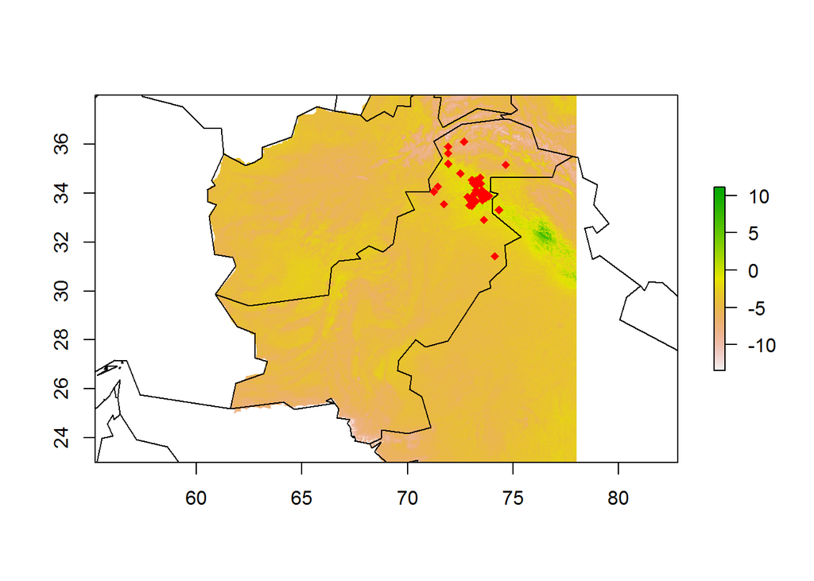

```r
pg <- predict(predictors,m1, ext=ext)
plot(pg)
plot(wrld_simpl, add=TRUE)
points(Parnara_bada, col="red", pch=18)
```

#### Cross-validation of the model “m1”

```r
evaluate(testpres, testbackg, m1)
```

```
## class          : ModelEvaluation
## n presences    : 7
## n absences     : 179
## AUC            : 0.764565
## cor            : 0.3292829
## max TPR+TNR at : -2.277786
```

# References

#### Hijmans, R.H., Elith, J. (2019): Spatial Distribution Models. https://rspatial.org/sdm/SDM.pdf Date: 10.Jan.2020.

#### Hijmans, R.H. (2019): Point pattern analysis. https://rspatial.org/raster/analysis/8-pointpat.html Date: 08.Jan.2020.